# Movie Analysis

```r
load("Movie.Rdata")
loadhistory("Movie.Rhistory")
```

```r
#save workspace
save.image("Movie.Rdata")
savehistory("Movie.Rhistory")
```

```r
# loading needed libraries
library(tidymodels)
```

```
• Search for functions across packages at https://www.tidymodels.org/find/
```

```r
library(tidyverse)
library(Hmisc)
library(corrplot)
```

## Reading The Data

```r
movie <- read_csv("movies.csv",
                 col_names = TRUE,
                 col_select = c("gross"
                                ,"budget"
                                ,"score"
                                ,"genre"
                                ,"country")
                )
```

```r
head(movie, 10)
```

| gross | budget | score | genre | country |
| --- | --- | --- | --- | --- |
| 46998772 | 1.9e+07 | 8.4 | Drama | United Kingdom |
| 58853106 | 4.5e+06 | 5.8 | Adventure | United States |
| 538375067 | 1.8e+07 | 8.7 | Action | United States |
| 83453539 | 3.5e+06 | 7.7 | Comedy | United States |
| 39846344 | 6.0e+06 | 7.3 | Comedy | United States |
| 39754601 | 5.5e+05 | 6.4 | Horror | United States |
| 115229890 | 2.7e+07 | 7.9 | Action | United States |
| 23402427 | 1.8e+07 | 8.2 | Biography | United States |
| 108185706 | 5.4e+07 | 6.8 | Action | United States |
| 15795189 | 1.0e+07 | 7.0 | Biography | United States |

## Preparing Categorical Data

Converting genre and country to factors with sensible number of levels

```r
# We first observe the distribution

movie %>% count(genre, sort = T) %>% head(5)
```

| genre | n |
| --- | --- |
| Comedy | 2245 |
| Action | 1705 |
| Drama | 1518 |
| Crime | 551 |
| Biography | 443 |

```r
movie %>% count (country, sort = T) %>% head(5)
```

| country | n |
| --- | --- |
| United States | 5475 |
| United Kingdom | 816 |
| France | 279 |
| Canada | 190 |
| Germany | 117 |

```r
# reducing the number of levels for genre and country and subsequently making them factors
movie1 <-
movie %>% mutate(genre = ifelse(genre %in% c("Comedy", "Action", "Drama"),genre, "Others")
                 %>% as.factor(),
                 country = ifelse(country != "United States","Others", country)
                 %>% as.factor())
```

```r
# rechecking if the conversion is successful
movie1 %>% count(genre, sort = T) %>% head(5)
```

| genre | n |
| --- | --- |
| Comedy | 2245 |
| Others | 2200 |
| Action | 1705 |
| Drama | 1518 |

```r
movie1 %>% count (country, sort = T) %>% head(5)
```

| country | n |
| --- | --- |
| United States | 5475 |
| Others | 2190 |
| NA | 3 |

```r
head(movie1, 10)
```

| gross | budget | score | genre | country |
| --- | --- | --- | --- | --- |
| 46998772 | 1.9e+07 | 8.4 | Drama | Others |
| 58853106 | 4.5e+06 | 5.8 | Others | United States |
| 538375067 | 1.8e+07 | 8.7 | Action | United States |
| 83453539 | 3.5e+06 | 7.7 | Comedy | United States |
| 39846344 | 6.0e+06 | 7.3 | Comedy | United States |
| 39754601 | 5.5e+05 | 6.4 | Others | United States |
| 115229890 | 2.7e+07 | 7.9 | Action | United States |
| 23402427 | 1.8e+07 | 8.2 | Others | United States |
| 108185706 | 5.4e+07 | 6.8 | Action | United States |
| 15795189 | 1.0e+07 | 7.0 | Others | United States |

## Cleaning Up Columns

```r
movie1 %>% map(~sum(is.na(.)))
```

```
$gross
[1] 189

$budget
[1] 2171

$score
[1] 3

$genre
[1] 0

$country
[1] 3
```

Since there are several missing data, I decided to do listwise deletion. I chose this method because I believe that the dataset is large enough even though some are deleted.

```r
movie1 <- movie1 %>% drop_na(budget, gross, country)
```

```r
movie1 %>% map(~sum(is.na(.)))
```

```
$gross
[1] 0

$budget
[1] 0

$score
[1] 0

$genre
[1] 0

$country
[1] 0
```

## Exploratory Data Analysis

```r
# Splitting the data into training and testing sets

set.seed(1234)
movie_split <- initial_split(movie1, prop = 0.8)
movie_training <- training(movie_split)
movie_testing <- testing(movie_split)
```

```r
# Descriptive statistics
summary(movie_training)
```

```
     gross               budget              score          genre               country
 Min.   :3.090e+02   Min.   :     6000   Min.   :1.900   Action:1109   Others       : 908
 1st Qu.:1.059e+07   1st Qu.: 10000000   1st Qu.:5.800   Comedy:1212   United States:3440
 Median :3.686e+07   Median : 22000000   Median :6.500   Drama : 714
 Mean   :1.024e+08   Mean   : 35864495   Mean   :6.392   Others:1313
 3rd Qu.:1.126e+08   3rd Qu.: 45000000   3rd Qu.:7.000
 Max.   :2.847e+09   Max.   :321000000   Max.   :9.300
```

```r
# Group by analysis for genre
movie_training %>% group_by(genre) %>%
           summarise(ave_gross = mean(gross),
                     ave_budget = mean(budget),
                     ave_score = mean(score))
```

| genre | ave_gross | ave_budget | ave_score |
| --- | --- | --- | --- |
| Action | 167817358 | 59277683 | 6.226330 |
| Comedy | 60109476 | 22749383 | 6.208086 |
| Drama | 59729299 | 23285686 | 6.719328 |
| Others | 109445975 | 35035524 | 6.522315 |

```r
# Group by analysis for country
movie_training %>% group_by(country) %>%
           summarise(ave_gross = mean(gross),
                     ave_budget = mean(budget),
                     ave_score = mean(score))
```

| country | ave_gross | ave_budget | ave_score |
| --- | --- | --- | --- |
| Others | 80254983 | 30155801 | 6.604626 |
| United States | 108267411 | 37371325 | 6.335349 |

```r
# Observing the distribution of the numerical data
par(mfrow=c(2,3))
hist(movie_training$gross)
hist(movie_training$budget)
```

```r
hist(movie_training$score)
boxplot(movie_training$gross)
```

[figure not shown]

```r
boxplot(movie_training$budget)
boxplot(movie_training$score)
```

```r
# correlation matrix for numeric data
cormatrix <-
movie_training %>% select("gross", "budget", "score") %>%
as.matrix() %>% rcorr()
```

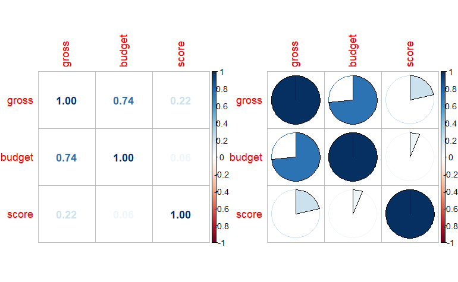

```r
# Visualizing the correlation matrix using a correlogram
par(mfrow=c(1,2))
corrplot(cormatrix$r, method = "number")
corrplot(cormatrix$r, method = "pie")
```

## Linear Regression - Building Models

In this part, I built two models with gross as the response variable. These models explain how the chosen predicted variable influence the change in gross income. Subsequently, these two models were subjected to test using measures, namely, root means square error and coefficient of determination to determine which performed better.

```r
lm_spec <- linear_reg() %>%
  set_engine(engine = "lm")
lm_spec
```

```
Linear Regression Model Specification (regression)

Computational engine: lm
```

### Model 1

```r
train_fit_1 <- lm_spec %>%
             fit(gross ~ budget + score + genre + country, data = movie_training)
train_fit_1
```

```
parsnip model object


Call:
stats::lm(formula = gross ~ budget + score + genre + country,
    data = data)

Coefficients:
         (Intercept)                budget                 score           genreComedy
          -2.378e+08             3.198e+00             3.303e+07             8.895e+06
          genreDrama           genreOthers  countryUnited States
          -8.048e+06             1.024e+07             1.291e+07
```

```r
train_results_1 <- train_fit_1 %>%
  predict(new_data = movie_training)  %>%
  mutate(truth = movie_training$gross)

head(train_results_1)
```

| .pred | truth |
| --- | --- |
| 92930371.2 | 83531958 |
| 31556643.1 | 459824 |
| 160363160.4 | 52323400 |
| -960020.9 | 24271196 |
| 30894197.1 | 12671109 |
| 13148374.2 | 46138887 |

```r
rmse(train_results_1, truth = truth, estimate = .pred)
```

| .metric | .estimator | .estimate |
| --- | --- | --- |
| rmse | standard | 118778653 |

```r
rsq(train_results_1, truth = truth, estimate = .pred)
```

| .metric | .estimator | .estimate |
| --- | --- | --- |
| rsq | standard | 0.5717206 |

## Model 2

```r
train_fit_2 <- lm_spec %>%
             fit(gross ~ poly(budget + score, 2, raw = T), data = movie_training)
train_fit_2
```

```
parsnip model object


Call:
stats::lm(formula = gross ~ poly(budget + score, 2, raw = T),
    data = data)

Coefficients:
                      (Intercept)  poly(budget + score, 2, raw = T)1
                        1.044e+07                          1.924e+00
poly(budget + score, 2, raw = T)2
                        7.721e-09
```

```r
train_results_2 <- train_fit_2 %>%
  predict(new_data = movie_training)  %>%
  mutate(truth = movie_training$gross)

head(train_results_2)
```

| .pred | truth |
| --- | --- |
| 61051517 | 83531958 |
| 38881547 | 459824 |
| 153650026 | 52323400 |
| 22257454 | 24271196 |
| 51998214 | 12671109 |
| 11208652 | 46138887 |

```r
rmse(train_results_2, truth = truth, estimate = .pred)
```

| .metric | .estimator | .estimate |
| --- | --- | --- |
| rmse | standard | 120661512 |

```r
rsq(train_results_2, truth = truth, estimate = .pred)
```

| .metric | .estimator | .estimate |
| --- | --- | --- |
| rsq | standard | 0.5580349 |

## Linear Regression - Testing the Models

```r
test_results_1 <- train_fit_1 %>%
  predict(new_data = movie_testing) %>%
  mutate(truth = movie_testing$gross)

head(test_results_1)
```

| .pred | truth |
| --- | --- |
| 92312866 | 46998772 |
| -1543253 | 39754601 |
| 29499600 | 30031783 |
| 150607371 | 3484523 |
| -8264088 | 6342668 |
| -2664119 | 24265659 |

```r
rmse(test_results_1, truth = truth, estimate = .pred)
```

| .metric | .estimator | .estimate |
| --- | --- | --- |
| rmse | standard | 131550641 |

```r
rsq(test_results_1, truth = truth, estimate = .pred)
```

| .metric | .estimator | .estimate |
| --- | --- | --- |
| rsq | standard | 0.6070186 |

```r
test_results_2 <- train_fit_2 %>%
  predict(new_data = movie_testing) %>%
  mutate(truth = movie_testing$gross)

head(test_results_2)
```

| .pred | truth |
| --- | --- |
| 49773501 | 46998772 |
| 11498289 | 39754601 |
| 20248937 | 30031783 |
| 110024287 | 3484523 |
| 16278225 | 6342668 |
| 23267505 | 24265659 |

```r
rmse(test_results_2, truth = truth, estimate = .pred)
```

| .metric | .estimator | .estimate |
| --- | --- | --- |
| rmse | standard | 128633630 |

```r
rsq(test_results_2, truth = truth, estimate = .pred)
```

| .metric | .estimator | .estimate |
| --- | --- | --- |
| rsq | standard | 0.625084 |

## Summary of the Models’ Performance

```r
model_names <- c("Model_1", "Model_2")
train_error <- c("118778653", "120661512")
test_error <- c("131550641", "128633630")
train_rsq <- c("0.5717206", "0.5580349")
test_rsq <- c("0.6070186", "0.625084")
comparison <- data.frame(model_names, train_error, test_error, train_rsq, test_rsq)
comparison
```

| model_names | train_error | test_error | train_rsq | test_rsq |
| --- | --- | --- | --- | --- |
| Model_1 | 118778653 | 131550641 | 0.5717206 | 0.6070186 |
| Model_2 | 120661512 | 128633630 | 0.5580349 | 0.625084 |

The performances of the two models are very interesting. Model 1 has a lower error and higher coefficient of determination compared with Model 2 in the TRAINING data set. However, Model 2 has a lower error and higher coefficient of determination compared with Model 1 in the TESTING data set.

This implies that Model 1 has a higher variance than Model 2. That said, Model 2 is better with prediction for data other that the testing set.